# Heteroskedasticity-robust tests in linear regression: A review and evaluation of small-sample corrections

James E. Pustejovsky and Gleb Furman

4/30/2017

# Linear regression

Let’s talk about a basic regression model:

$$\begin{aligned}
y_i &= \beta_0 + \beta_1 x_{1i} + \cdots + \beta_{p-1} x_{p-1,i} + e_i \\
\mathbf{y} &= \mathbf{X} \boldsymbol\beta + \mathbf{e}
\end{aligned}$$
estimated by ordinary least squares:

$$\boldsymbol{\hat\beta} = \left(\mathbf{X}'\mathbf{X}\right)^{-1} \mathbf{X}'\mathbf{y}.$$

- Classical inference methods assume homoskedasticity: $\text{Var}(e_i) = \sigma^2$
- But there are many settings where the we would rather allow for *heteroskedasticity of an unknown form*: $\text{Var}(e_i) = \sigma_i^2$
- One way to do inference in this setting is by using *heteroskedasticity-consistent covariance matrix estimators* (HCCMEs; Eicker, 1967; Huber, 1967; White, 1980).

# HCCMEs

- Variance of the OLS estimator:
  $$\text{Var}\left(\mathbf{c}'\boldsymbol{\hat\beta}\right) = \frac{1}{n} \mathbf{c}'\mathbf{M} \left(\frac{1}{n}\sum_{i=1}^n \sigma_i^2 \mathbf{x}_i\mathbf{x}_i'\right) \mathbf{M}\mathbf{c}, \qquad \mathbf{M} = \left(\frac{1}{n}\mathbf{X}'\mathbf{X}\right)^{-1}$$
- The original HCCME (sandwich) estimator:
  $$\mathbf{V}^{HC0} = \frac{1}{n} \mathbf{c}'\mathbf{M} \left(\frac{1}{n}\sum_{i=1}^n \hat{e}_i^2 \mathbf{x}_i\mathbf{x}_i'\right) \mathbf{M}\mathbf{c}$$
- HC0 is asymptotically consistent, but *biased* in small samples; hypothesis tests based on HC0 can have poor coverage in small samples.
- Features of design matrix (especially *leverage*) influence bias and coverage.

# Potential small-sample improvements

- Modified sandwich estimators (MacKinnon & White, 1985; Davidson & MacKinnon, 1993):
  $$\mathbf{V}^{HC0} = \frac{1}{n} \mathbf{c}'\mathbf{M} \left(\frac{1}{n}\sum_{i=1}^n \color{red}{\omega_i} \hat{e}_i^2 \mathbf{x}_i\mathbf{x}_i'\right) \mathbf{M}\mathbf{c}$$
  where
  $$\small
  \begin{aligned}
  \text{HC1:} \qquad \omega_i &= n / (n - p) \\
  \text{HC2:} \qquad \omega_i &= (1 - h_{ii})^{-1} \\
  \text{HC3:} \qquad \omega_i &= (1 - h_{ii})^{-2}
  \end{aligned}$$
- Long and Ervin (2000) conducted a comprehensive simulation study on hypothesis test coverage with HCCMEs, recommended HC3 as default.
- Subsequently (Cribari-Neto et al., 2004, 2007, 2011):
  $$\small
  \begin{aligned}
  \text{HC4:} \qquad \omega_i &= (1 - h_{ii})^{-\delta_i}, \qquad \delta_i = \min\{h_{ii} n / p, 4\} \\
  \text{HC4m:} \qquad \omega_i &= (1 - h_{ii})^{-\delta_i}, \qquad \delta_i = \min\left\{h_{ii} n / p, 1 \right\} + \min\left\{h_{ii} n / p, 1.5 \right\} \\
  \text{HC5:} \qquad \omega_i &= (1 - h_{ii})^{-\delta_i}, \qquad \delta_i = \min\left\{h_{ii} n / p, \max \left\{4, 0.7 h_{(n)(n)} n / p\right\}\right\}
  \end{aligned}$$

# Other potential small-sample improvements

Approximations for the reference distribution of test statistic:

- Satterthwaite approximation (Lipsitz, Ibrahim, & Parzen, 1999)
- Edgeworth approximation (Kauermann & Carroll, 2001)
- Saddlepoint approximation (McCaffrey & Bell, 2006)
- All three approximations developed assuming a homoskedastic “working model” for the error structure.
- These approaches have been largely ignored. Never compared to HC* variants or to each other.

# Simulations

- Simple regression with one predictor:
  $$y_i = \beta_0 + \beta_1 x_i + \sigma_i e_i$$
- Predictor variable $x_i \sim \chi^2$ with varying degrees of skewness
- Errors $e_i \sim N(0, 1)$, $t_5$, or $\chi^2_5$
- Skedasticity function $\sigma_i = \exp(\zeta x_i)$, $\zeta = 0.00,0.02,0.04,...,0.20$
- sample sizes of $n = 25, 50, 100$
- Target Type-I error rates of $\alpha = .05, .01, .005$
- Rejection rates estimated from 50000 replications

# Size of HC* variants, $\alpha = .05$

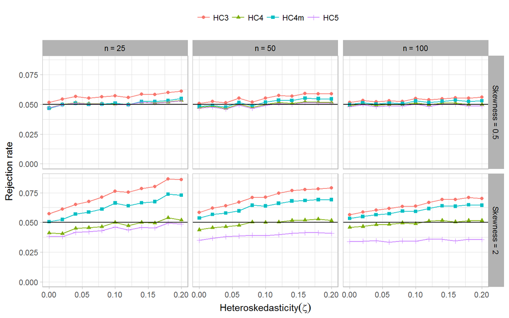

# Size of HC* variants, $\alpha = .01$

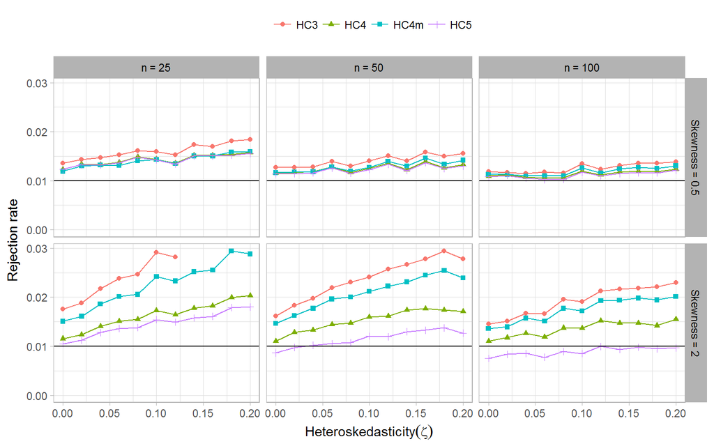

# Size of HC* variants, $\alpha = .005$

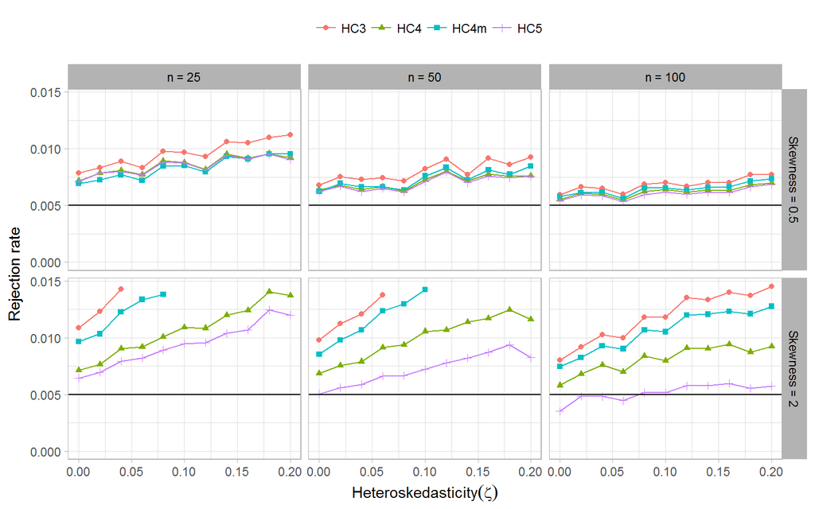

# Size of selected tests, $\alpha = .05$

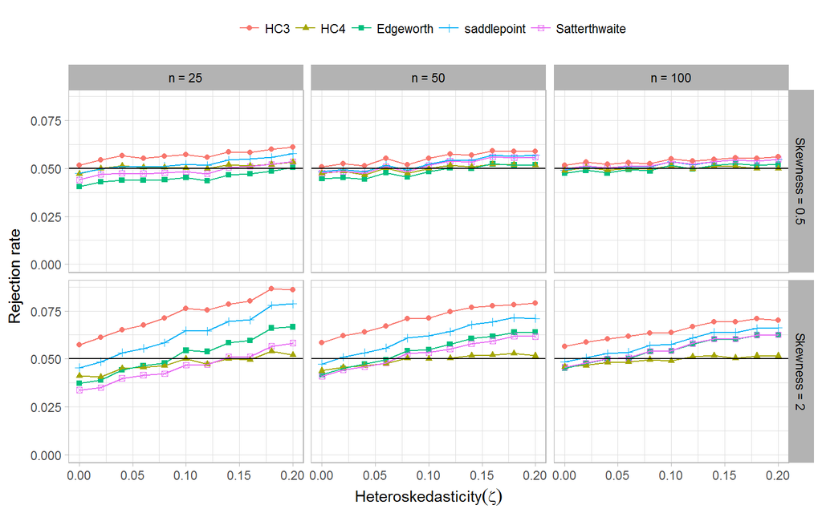

# Size of selected tests, $\alpha = .01$

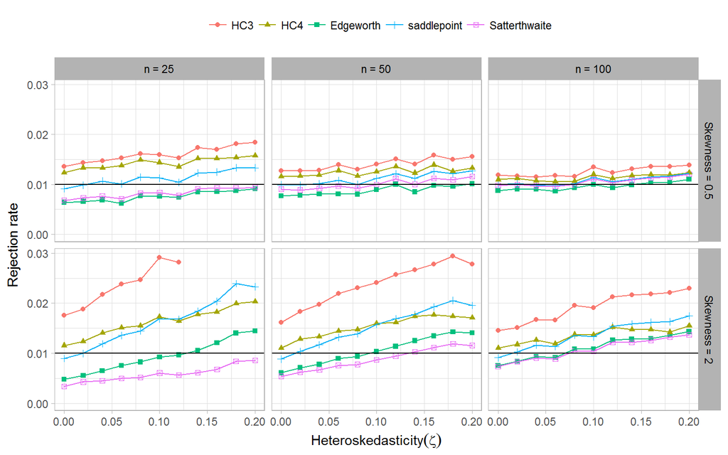

# Size of selected tests, $\alpha = .005$

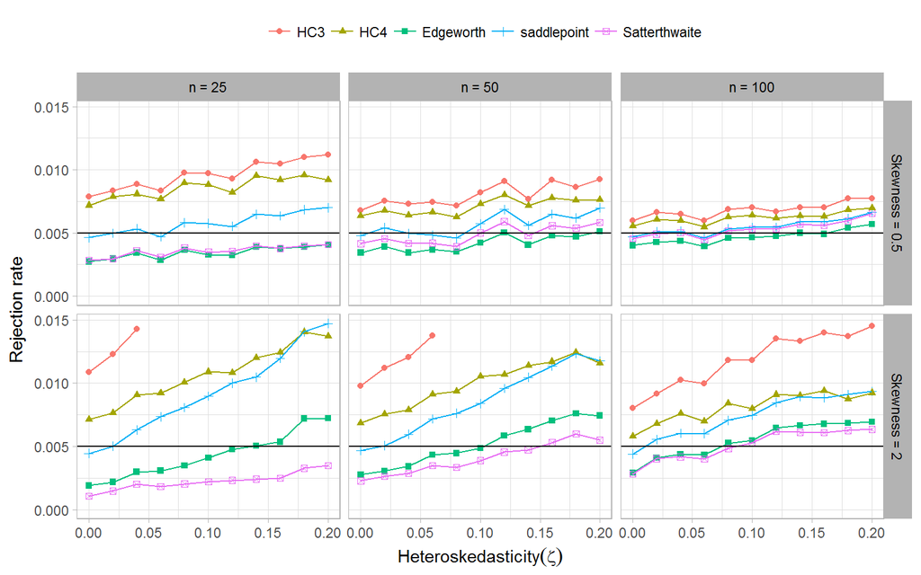

# Findings

1. Currently recommended test HC3 does not adequately control type-I error rate.
2. At the $\alpha = .05$ level, HC4 maintains most accurate rejection rates of all tests considered.
3. At smaller $\alpha$ levels, Satterthwaite and Edgeworth approximations out-perform HC3 and HC4.

# Discussion

- In ongoing work, we are examining the relative power of tests (after size adjustment)
- Generality of findings requires further investigation (covariate distribution, skedasticity function, number of predictors)
- Distributional approximations warrant wider consideration because they can be generalized to more complex models.

# References

Cribari-Neto, F. (2004). Asymptotic inference under heteroskedasticity of unknown form. Computational Statistics and Data Analysis, 45(2), 215-233.

Cribari-Neto, F., Souza, T. C., & Vasconcellos, K. L. P. (2007). Inference under heteroskedasticity and leveraged data. Communications in Statistics - Theory and Methods, 36(10), 1877-1888.

Cribari-Neto, F., & da Silva, W. B. (2011). A new heteroskedasticity-consistent covariance matrix estimator for the linear regression model. Advances in Statistical Analysis, 95(2), 129-146.

Davidson, R., & MacKinnon, J. G. (1993). Estimation and Inference in Econometrics. New York, NY: Oxford University Press.

Eicker, F. (1967). Limit theorems for regressions with unequal and dependent errors. In Proceedings of the Berkeley Symposium on Mathematical Statistics and Probability (Vol. 1, pp. 59-82). Berkeley, CA: University of California Press.

Huber, P. J. (1967). The behavior of maximum likelihood estimates under nonstandard conditions. In Proceedings of the fifth Berkeley symposium on Mathematical Statistics and Probability (pp. 221-233). Berkeley, CA: University of California Press.

Kauermann, G., & Carroll, R. J. (2001). A note on the efficiency of sandwich covariance matrix estimation. Journal of the American Statistical Association, 96(456), 1387-1396.

Lipsitz, S. R., Ibrahim, J. G., & Parzen, M. (1999). A degrees-of-freedom approximation for a t-statistic with heterogeneous variance. Journal of the Royal Statistical Society: Series D (The Statistician), 48(4), 495-506.

Long, J. S., & Ervin, L. H. (2000). Using heteroscedasticity consistent standard errors in the linear regression model. The American Statistician, 54(3), 217-224.

MacKinnon, J. G., & White, H. (1985). Some heteroskedasticity-consistent covariance matrix estimators with improved finite sample properties. Journal of Econometrics, 29, 305-325.

McCaffrey, D. F., & Bell, R. M. (2006). Improved hypothesis testing for coefficients in generalized estimating equations with small samples of clusters. Statistics in Medicine, 25(23), 4081-98.

White, H. (1980). A heteroskedasticity-consistent covariance matrix estimator and a direct test for heteroskedasticity. Econometrica, 48(4), 817-838.

# Degree of heteroskedasticity

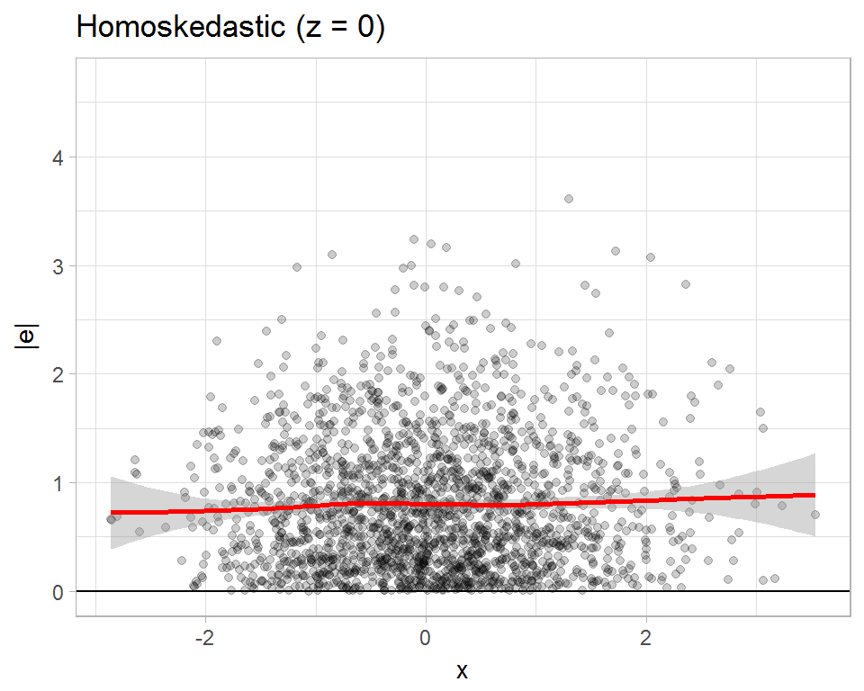

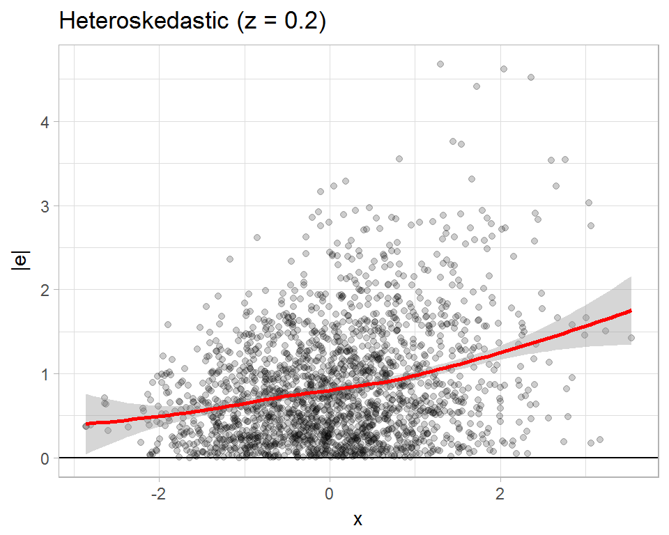